—https://github.com/Xuuuyeah/p8130_final.git title: “p8130_final” author: “Yiran Xu” date: “2024-12-07” output: html_document —

### 目前遇到的问题：

建模用的是AFT model, assume “weibull” distribution. 但是输出结果后发现survival months不属于”weibull” distribution (根据残差是否是normal的方法),同样也拒绝了log- normal distribution.

由于找不到假设的分布，使用非参数方法COX model后cross validation的结果很差，mean_cindex只有0.2+，所以目前先保留了AFT的方法，还在看怎么解决不符合分布的问题。。。

### 剩下的任务：

- outlier detection: Cook’s distance
- 可以在尝试一下LASSO，但这个dataset dimension小，不一定适合用lasso，stepwise就够
- evaluation: prediction risk = bias^2 + var?
- readability

### Yiran To-do list

- 还没有完成不同种族间的比较 - stratification and rerun Weibull
- model里只有三个main effect, 应该把其他的main effect都加上？（之前因为有interaction所以没加上）
- model explanation: need to output “survival_month = 0.1x + 0.2y + …”
- month不需要transform，因为假设的不是normal
- If the interaction term is NOT significant, remove it and re-fit the model only with the main effects
- use the compound variable “Regional Node Positive/Regional Node Examined”, instead of the two individual variables

#### Done

- transformation, reginol_node_positive还没找到合适的transformation，survival
- whatever
- 怎么解决不符合分布的问题 (已解决,未修改：according to lec 12: In large samples, the test is very sensitive to departures from normality, we could still assume a distribution given the residual is not normal, use qq plot is enough)

```r
library(readr)
library(dplyr)
library(survival)
library(caret)
```

```r
library(ggplot2)
library(patchwork)
library(kableExtra)
library(minerva)
library(stats)
library(fitdistrplus)
library(randomForestSRC)
library(tidyverse)
library(goftest)
library(survival)
library(stats)
library(broom)
library(flexsurv)
```

# Data Wrangling

## Loading and cleaning the data

```r
data_clean = read_csv("data/Project_2_data.csv") |>
  rename(
    Stage_6th = `6th Stage`) |>
  janitor::clean_names() |>

mutate(status = as.numeric(status == "Dead"),
       race = as.factor(race),
       marital_status = as.factor(marital_status),
       t_stage = as.factor(t_stage),
       n_stage = as.factor(n_stage),
       stage_6th = as.factor(stage_6th),
       differentiate = as.factor(differentiate),
       grade = as.factor(grade),
       a_stage = as.factor(a_stage),
       estrogen_status = as.factor(estrogen_status),
       progesterone_status = as.factor(progesterone_status),
       survival_months = log(survival_months) + 1
  )
summary(data_clean)
```

```
##       age           race        marital_status t_stage   n_stage   stage_6th
##  Min.   :30.00   Black: 291   Divorced : 486   T1:1603   N1:2732   IIA :1305
##  1st Qu.:47.00   Other: 320   Married  :2643   T2:1786   N2: 820   IIB :1130
##  Median :54.00   White:3413   Separated:  45   T3: 533   N3: 472   IIIA:1050
##  Mean   :53.97                Single   : 615   T4: 102             IIIB:  67
##  3rd Qu.:61.00                Widowed  : 235                       IIIC: 472
##  Max.   :69.00
##                    differentiate                   grade          a_stage
##  Moderately differentiated:2351   1                   : 543   Distant :  92
##  Poorly differentiated    :1111   2                   :2351   Regional:3932
##  Undifferentiated         :  19   3                   :1111
##  Well differentiated      : 543   anaplastic; Grade IV:  19
##
##
##    tumor_size     estrogen_status progesterone_status regional_node_examined
##  Min.   :  1.00   Negative: 269   Negative: 698       Min.   : 1.00
##  1st Qu.: 16.00   Positive:3755   Positive:3326       1st Qu.: 9.00
##  Median : 25.00                                       Median :14.00
##  Mean   : 30.47                                       Mean   :14.36
##  3rd Qu.: 38.00                                       3rd Qu.:19.00
##  Max.   :140.00                                       Max.   :61.00
##  regional_node_positive survival_months     status
##  Min.   : 1.000         Min.   :1.000   Min.   :0.0000
##  1st Qu.: 1.000         1st Qu.:5.025   1st Qu.:0.0000
##  Median : 2.000         Median :5.290   Median :0.0000
##  Mean   : 4.158         Mean   :5.184   Mean   :0.1531
##  3rd Qu.: 5.000         3rd Qu.:5.500   3rd Qu.:0.0000
##  Max.   :46.000         Max.   :5.673   Max.   :1.0000
```

```r
head(data_clean) |>
  kable() |>
  kable_styling(full_width = FALSE) %>%
  scroll_box(width = "100%", height = "300px")
```

| age | race | marital_status | t_stage | n_stage | stage_6th | differentiate | grade | a_stage | tumor_size | estrogen_status | progesterone_status | regional_node_examined | regional_node_positive | survival_months | status |
| --- | --- | --- | --- | --- | --- | --- | --- | --- | --- | --- | --- | --- | --- | --- | --- |
| 68 | White | Married | T1 | N1 | IIA | Poorly differentiated | 3 | Regional | 4 | Positive | Positive | 24 | 1 | 5.094345 | 0 |
| 50 | White | Married | T2 | N2 | IIIA | Moderately differentiated | 2 | Regional | 35 | Positive | Positive | 14 | 5 | 5.127134 | 0 |
| 58 | White | Divorced | T3 | N3 | IIIC | Moderately differentiated | 2 | Regional | 63 | Positive | Positive | 14 | 7 | 5.317488 | 0 |
| 58 | White | Married | T1 | N1 | IIA | Poorly differentiated | 3 | Regional | 18 | Positive | Positive | 2 | 1 | 5.430817 | 0 |
| 47 | White | Married | T2 | N1 | IIB | Poorly differentiated | 3 | Regional | 41 | Positive | Positive | 3 | 1 | 4.912023 | 0 |
| 51 | White | Single | T1 | N1 | IIA | Moderately differentiated | 2 | Regional | 20 | Positive | Positive | 18 | 2 | 5.488636 | 0 |

## Exploratory Data Analysis

```r
summary_stats <- data_clean |> summary()
print(summary_stats)
```

```
##       age           race        marital_status t_stage   n_stage   stage_6th
##  Min.   :30.00   Black: 291   Divorced : 486   T1:1603   N1:2732   IIA :1305
##  1st Qu.:47.00   Other: 320   Married  :2643   T2:1786   N2: 820   IIB :1130
##  Median :54.00   White:3413   Separated:  45   T3: 533   N3: 472   IIIA:1050
##  Mean   :53.97                Single   : 615   T4: 102             IIIB:  67
##  3rd Qu.:61.00                Widowed  : 235                       IIIC: 472
##  Max.   :69.00
##                    differentiate                   grade          a_stage
##  Moderately differentiated:2351   1                   : 543   Distant :  92
##  Poorly differentiated    :1111   2                   :2351   Regional:3932
##  Undifferentiated         :  19   3                   :1111
##  Well differentiated      : 543   anaplastic; Grade IV:  19
##
##
##    tumor_size     estrogen_status progesterone_status regional_node_examined
##  Min.   :  1.00   Negative: 269   Negative: 698       Min.   : 1.00
##  1st Qu.: 16.00   Positive:3755   Positive:3326       1st Qu.: 9.00
##  Median : 25.00                                       Median :14.00
##  Mean   : 30.47                                       Mean   :14.36
##  3rd Qu.: 38.00                                       3rd Qu.:19.00
##  Max.   :140.00                                       Max.   :61.00
##  regional_node_positive survival_months     status
##  Min.   : 1.000         Min.   :1.000   Min.   :0.0000
##  1st Qu.: 1.000         1st Qu.:5.025   1st Qu.:0.0000
##  Median : 2.000         Median :5.290   Median :0.0000
##  Mean   : 4.158         Mean   :5.184   Mean   :0.1531
##  3rd Qu.: 5.000         3rd Qu.:5.500   3rd Qu.:0.0000
##  Max.   :46.000         Max.   :5.673   Max.   :1.0000
```

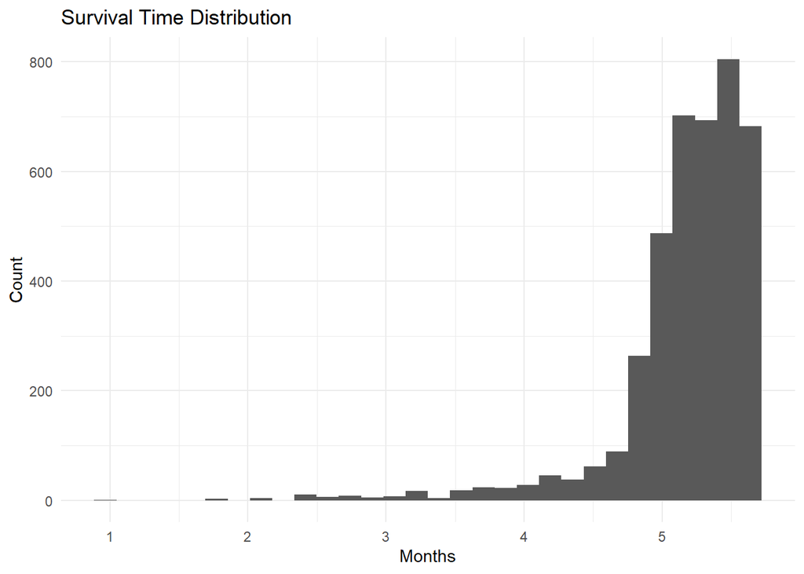

```r
data_clean |> ggplot(aes(x = survival_months, fill = status)) +
  geom_histogram() +
  labs(title = "Survival Time Distribution", x = "Months", y = "Count") +
  theme_minimal()
```

Create a table for the description of each variable

```r
# Create a data frame for variable descriptions
variable_descriptions <- data.frame(
  Variable = c(
    "Age", "Race", "Marital Status", "T Stage (Tumor)", "N Stage (Node)",
    "Stage (6th Edition)", "Differentiate", "Grade", "A Stage",
    "Tumor Size", "Estrogen Status", "Progesterone Status",
    "Regional Nodes Examined", "Regional Nodes Positive",
    "Survival Months", "Status"
  ),
  Description = c(
    "Patient's age at the time of diagnosis or study enrollment.",
    "Patient's racial identity: Black, White, Other.",
    "Patient's marital status: Married, Single, Divorced, Separated, Widowed.",
    "Tumor size and extent: T1 (≤2 cm), T2 (>2 cm but ≤5 cm), T3 (>5 cm), T4 (invasion into chest wall or skin).",
    "Lymph node involvement: N1 (1–3 nodes), N2 (4–9 nodes), N3 (≥10 nodes).",
    "Overall cancer stage: IIA, IIB, IIIA, IIIB, IIIC.",
    "Tumor differentiation level: Well, Moderately, Poorly, Undifferentiated.",
    "Tumor histological grade: Grade 1 (low), Grade 2 (moderate), Grade 3 (high), Grade IV (anaplastic).",
    "Extent of cancer spread: Regional (local spread), Distant (metastasized).",
    "Size of the tumor in millimeters.",
    "Tumor's estrogen receptor status: Positive, Negative.",
    "Tumor's progesterone receptor status: Positive, Negative.",
    "Number of regional lymph nodes examined for cancer.",
    "Number of regional lymph nodes found to be cancer-positive.",
    "Number of months the patient survived after diagnosis or study enrollment.",
    "Patient's status at the end of the study: Alive, Deceased."
  )
)

# Display the table
kable(variable_descriptions, col.names = c("Variable", "Description"),
      caption = "Variable Descriptions in the Breast Cancer Dataset", align = "l")
```

Variable Descriptions in the Breast Cancer Dataset

| Variable | Description |
| --- | --- |
| Age | Patient’s age at the time of diagnosis or study enrollment. |
| Race | Patient’s racial identity: Black, White, Other. |
| Marital Status | Patient’s marital status: Married, Single, Divorced, Separated, Widowed. |
| T Stage (Tumor) | Tumor size and extent: T1 (≤2 cm), T2 (>2 cm but ≤5 cm), T3 (>5 cm), T4 (invasion into chest wall or skin). |
| N Stage (Node) | Lymph node involvement: N1 (1–3 nodes), N2 (4–9 nodes), N3 (≥10 nodes). |
| Stage (6th Edition) | Overall cancer stage: IIA, IIB, IIIA, IIIB, IIIC. |
| Differentiate | Tumor differentiation level: Well, Moderately, Poorly, Undifferentiated. |
| Grade | Tumor histological grade: Grade 1 (low), Grade 2 (moderate), Grade 3 (high), Grade IV (anaplastic). |
| A Stage | Extent of cancer spread: Regional (local spread), Distant (metastasized). |
| Tumor Size | Size of the tumor in millimeters. |
| Estrogen Status | Tumor’s estrogen receptor status: Positive, Negative. |
| Progesterone Status | Tumor’s progesterone receptor status: Positive, Negative. |
| Regional Nodes Examined | Number of regional lymph nodes examined for cancer. |
| Regional Nodes Positive | Number of regional lymph nodes found to be cancer-positive. |
| Survival Months | Number of months the patient survived after diagnosis or study enrollment. |
| Status | Patient’s status at the end of the study: Alive, Deceased. |

Side-by-Side Histograms for Categorical Variables

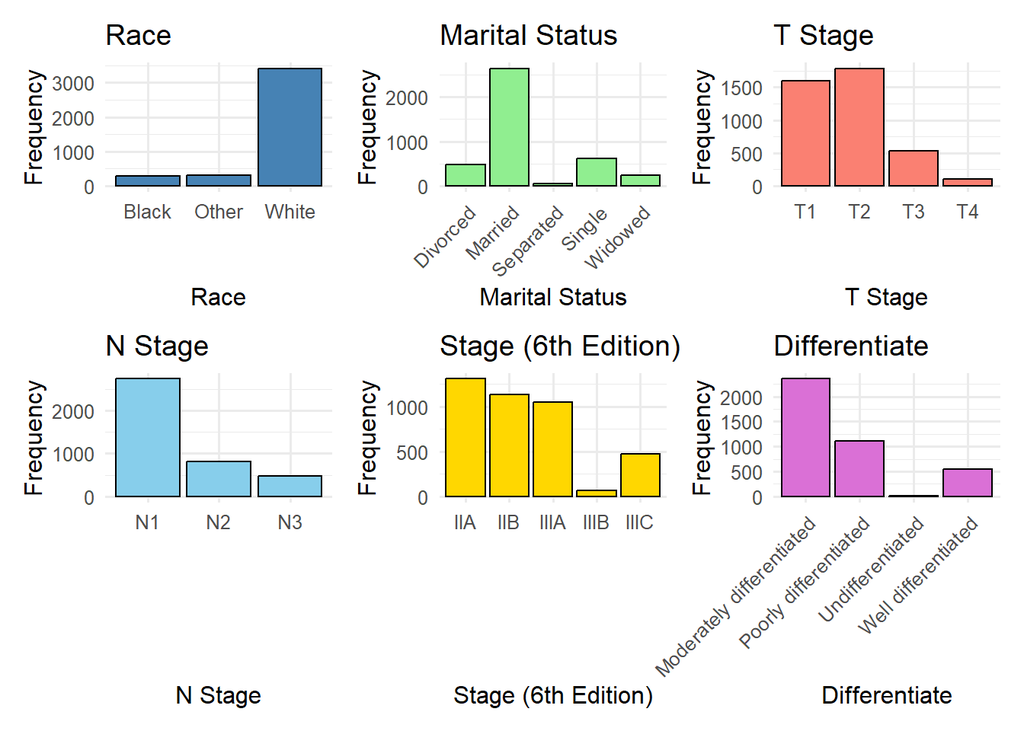

```r
# Histogram for `race`
plot_race <- ggplot(data_clean, aes(x = race)) +
  geom_bar(fill = "steelblue", color = "black") +
  labs(title = "Race", x = "Race", y = "Frequency") +
  theme_minimal(base_size = 12)

# Histogram for `marital_status`
plot_marital_status <- ggplot(data_clean, aes(x = marital_status)) +
  geom_bar(fill = "lightgreen", color = "black") +
  labs(title = "Marital Status", x = "Marital Status", y = "Frequency") +
  theme_minimal(base_size = 12) +
  theme(axis.text.x = element_text(angle = 45, hjust = 1))

# Histogram for `t_stage`
plot_t_stage <- ggplot(data_clean, aes(x = t_stage)) +
  geom_bar(fill = "salmon", color = "black") +
  labs(title = "T Stage", x = "T Stage", y = "Frequency") +
  theme_minimal(base_size = 12)

# Histogram for `n_stage`
plot_n_stage <- ggplot(data_clean, aes(x = n_stage)) +
  geom_bar(fill = "skyblue", color = "black") +
  labs(title = "N Stage", x = "N Stage", y = "Frequency") +
  theme_minimal(base_size = 12)

# Histogram for `stage_6th`
plot_stage_6th <- ggplot(data_clean, aes(x = stage_6th)) +
  geom_bar(fill = "gold", color = "black") +
  labs(title = "Stage (6th Edition)", x = "Stage (6th Edition)", y = "Frequency") +
  theme_minimal(base_size = 12)

# Histogram for `differentiate`
plot_differentiate <- ggplot(data_clean, aes(x = differentiate)) +
  geom_bar(fill = "orchid", color = "black") +
  labs(title = "Differentiate", x = "Differentiate", y = "Frequency") +
  theme_minimal(base_size = 12) +
  theme(axis.text.x = element_text(angle = 45, hjust = 1))

# Histogram for `grade`
plot_grade <- ggplot(data_clean, aes(x = as.factor(grade))) +
  geom_bar(fill = "coral", color = "black") +
  labs(title = "Grade", x = "Grade", y = "Frequency") +
  theme_minimal(base_size = 12)

# Histogram for `a_stage`
plot_a_stage <- ggplot(data_clean, aes(x = a_stage)) +
  geom_bar(fill = "plum", color = "black") +
  labs(title = "A Stage", x = "A Stage", y = "Frequency") +
  theme_minimal(base_size = 12)

# Histogram for `estrogen_status`
plot_estrogen_status <- ggplot(data_clean, aes(x = estrogen_status)) +
  geom_bar(fill = "lightblue", color = "black") +
  labs(title = "Estrogen Status", x = "Estrogen Status", y = "Frequency") +
  theme_minimal(base_size = 12)

# Histogram for `progesterone_status`
plot_progesterone_status <- ggplot(data_clean, aes(x = progesterone_status)) +
  geom_bar(fill = "yellow", color = "black") +
  labs(title = "Progesterone Status", x = "Progesterone Status", y = "Frequency") +
  theme_minimal(base_size = 12)

# Histogram for `status`
plot_status <- ggplot(data_clean, aes(x = as.factor(status))) +
  geom_bar(fill = "lightgreen", color = "black") +
  labs(title = "Status", x = "Status", y = "Frequency") +
  theme_minimal(base_size = 12)

# Combine all plots into a grid using patchwork
## Panel 1: First set of plots
panel_1 <- (plot_race | plot_marital_status | plot_t_stage) /
           (plot_n_stage | plot_stage_6th | plot_differentiate)

## Panel 2: Second set of plots
panel_2 <- (plot_grade | plot_a_stage | plot_estrogen_status) /
           (plot_progesterone_status | plot_status)

## Display Panel 1
panel_1
```

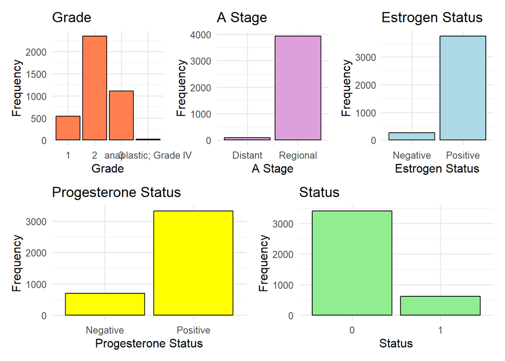

```r
## Display Panel 2
panel_2
```

Side-by-Side Histograms for Numerical Variables

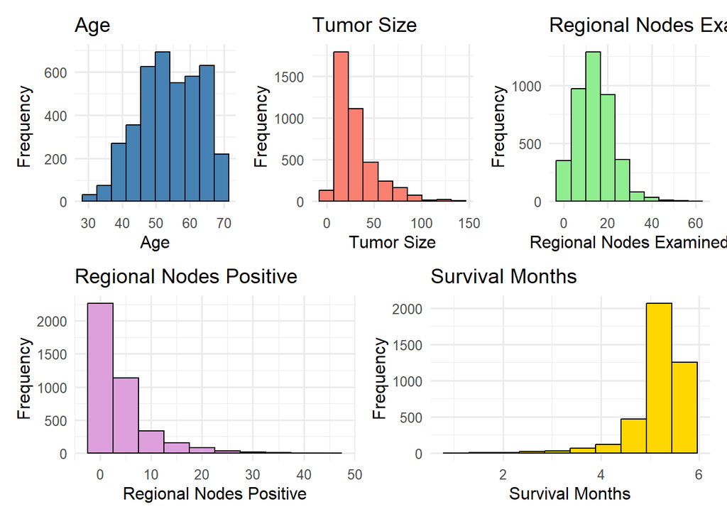

```r
## Create Individual Plots for Numeric Variables
plot_age <- ggplot(data_clean, aes(x = age)) +
  geom_histogram(fill = "steelblue", color = "black", bins = 10) +
  labs(title = "Age", x = "Age", y = "Frequency") +
  theme_minimal(base_size = 12)

plot_tumor_size <- ggplot(data_clean, aes(x = tumor_size)) +
  geom_histogram(fill = "salmon", color = "black", bins = 10) +
  labs(title = "Tumor Size", x = "Tumor Size", y = "Frequency") +
  theme_minimal(base_size = 12)

plot_regional_node_examined <- ggplot(data_clean, aes(x = regional_node_examined)) +
  geom_histogram(fill = "lightgreen", color = "black", bins = 10) +
  labs(title = "Regional Nodes Examined", x = "Regional Nodes Examined", y = "Frequency") +
  theme_minimal(base_size = 12)

plot_regional_node_positive <- ggplot(data_clean, aes(x = regional_node_positive)) +
  geom_histogram(fill = "plum", color = "black", bins = 10) +
  labs(title = "Regional Nodes Positive", x = "Regional Nodes Positive", y = "Frequency") +
  theme_minimal(base_size = 12)

plot_survival_months <- ggplot(data_clean, aes(x = survival_months)) +
  geom_histogram(fill = "gold", color = "black", bins = 10) +
  labs(title = "Survival Months", x = "Survival Months", y = "Frequency") +
  theme_minimal(base_size = 12)

(plot_age | plot_tumor_size | plot_regional_node_examined) /
                 (plot_regional_node_positive | plot_survival_months)
```

# Transformation

```r
data_clean$log_tumor_size <- log1p(data_clean$tumor_size)
data_clean$log_nodes_examined <- log1p(data_clean$regional_node_examined)
# data_clean$log_nodes_positive <- log1p(data_clean$regional_node_positive)
# not useful
# data_clean$log_survival_months <- log1p(data_clean$survival_months)
# not useful


## Create individual plots
plot_log_tumor_size <- ggplot(data_clean, aes(x = log_tumor_size)) +
  geom_histogram(fill = "steelblue", color = "black", bins = 10) +
  labs(title = "Log Tumor Size", x = "Log(Tumor Size)", y = "Frequency") +
  theme_minimal(base_size = 12)

plot_log_nodes_examined <- ggplot(data_clean, aes(x = log_nodes_examined)) +
  geom_histogram(fill = "salmon", color = "black", bins = 10) +
  labs(title = "Log Regional Nodes Examined", x = "Log(Regional Nodes Examined)", y = "Frequency") +
  theme_minimal(base_size = 12)


  theme_minimal(base_size = 12)
```

[output not shown]

[output cut: 240 more lines]

[output not shown]

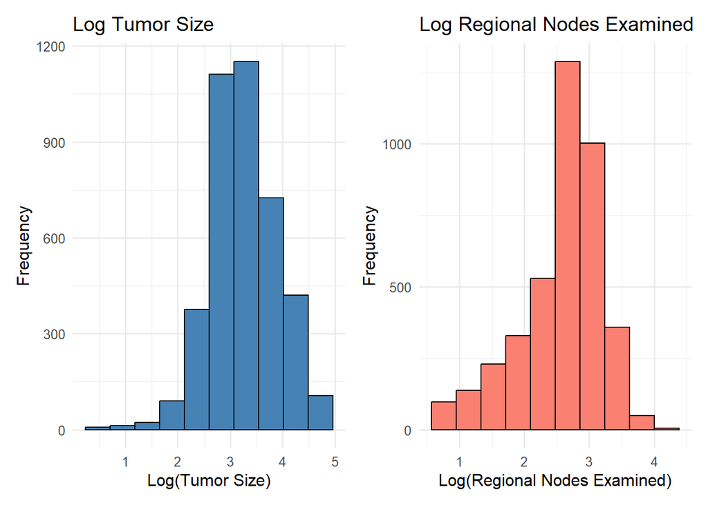

```r
## Combine the plots into a panel using patchwork
(plot_log_tumor_size | plot_log_nodes_examined)
```

## optional: 数值变量分布： 可以绘制直方图或箱线图检查是否有极端值?

# Apply AFT method

## Check survival rate distribution.

```r
# Weibull 分布拟合
fit_weibull <- fitdist(data_clean$survival_months, "weibull")

ad_test <- ad.test(data_clean$survival_months, "pweibull",
                   shape = fit_weibull$estimate["shape"],
                   scale = fit_weibull$estimate["scale"])
print("Anderson-Darling Test:")
```

```
## [1] "Anderson-Darling Test:"
```

```r
print(ad_test)
```

```
##
##  Anderson-Darling test of goodness-of-fit
##  Null hypothesis: Weibull distribution
##  with parameters shape = 17.6218561294872, scale = 5.35628924372155
##  Parameters assumed to be fixed
##
## data:  data_clean$survival_months
## An = 55.097, p-value = 1.491e-07
```

[figure not shown]

```r
fit_lognormal <- fitdist(data_clean$survival_months, "lnorm")
plot(fit_lognormal)
```

[figure not shown]

```r
# 绘制拟合效果
plot(fit_weibull)
```

The figure above shows that the distribution is either not Weibull or log-normal test, this is because the survival months data is truncated. If the residual is normal distribution, then we can say the theoriotical survival months obey certain distribution.

## Stepwise: initial filtering of variables

### stepwise

```r
full_model <- survreg(Surv(survival_months, status) ~ ., data = data_clean, dist = "weibull")


stepwise_model <- stepAIC(full_model, direction = "both", trace = FALSE)

selected_formula <- formula(stepwise_model)
selected_variables <- all.vars(selected_formula)[-1][-1]
print(selected_variables)
```

```
## [1] "age"                    "race"                   "t_stage"
## [4] "n_stage"                "differentiate"          "estrogen_status"
## [7] "progesterone_status"    "regional_node_examined" "regional_node_positive"
```

```r
selected_vars <- all.vars(selected_formula)[-1][-1]
selected_vars = data_clean[, selected_vars, drop = FALSE]

perform_chi_square_all <- function(data) {
  results <- data.frame(
    Variable1 = character(),
    Variable2 = character(),
    Chi_Square_Statistic = numeric(),
    P_Value = numeric(),
    stringsAsFactors = FALSE
  )

  # 遍历所有变量组合
  var_names <- names(data)
  for (i in 1:(length(var_names) - 1)) {
    for (j in (i + 1):length(var_names)) {
      var1 <- var_names[i]
      var2 <- var_names[j]

      # 卡方检验
      contingency_table <- table(data[[var1]], data[[var2]])
      chi_test <- chisq.test(contingency_table)

      # 存储结果
      results <- rbind(results, data.frame(
        Variable1 = var1,
        Variable2 = var2,
        Chi_Square_Statistic = chi_test$statistic,
        P_Value = chi_test$p.value
      ))
    }
  }
  significant_results <- subset(results, P_Value < 0.05)
  return(significant_results)
}

# 假设 data_clean 全是因子类型数据
# 应用到你的数据集
chi_square_results <- perform_chi_square_all(selected_vars) |>
  arrange(P_Value)
# 打印结果
print(chi_square_results)
```

```
##                          Variable1              Variable2 Chi_Square_Statistic
## X-squared25                n_stage regional_node_positive           7250.80335
## X-squared35 regional_node_examined regional_node_positive          13015.66055
## X-squared30        estrogen_status    progesterone_status           1054.84312
## X-squared24                n_stage regional_node_examined            724.42063
## X-squared15                t_stage                n_stage            323.41371
## X-squared20                t_stage regional_node_positive            577.47451
## X-squared26          differentiate        estrogen_status            217.41670
## X-squared27          differentiate    progesterone_status            147.80315
## X-squared21                n_stage          differentiate            115.50114
## X-squared16                t_stage          differentiate             90.95689
## X-squared22                n_stage        estrogen_status             42.52308
## X-squared29          differentiate regional_node_positive            224.69837
## X-squared32        estrogen_status regional_node_positive            112.19044
## X-squared23                n_stage    progesterone_status             36.84600
## X-squared19                t_stage regional_node_examined            246.37398
## X-squared                      age                   race            136.89714
## X-squared10                   race          differentiate             27.90280
## X-squared17                t_stage        estrogen_status             19.54986
## X-squared34    progesterone_status regional_node_positive             75.04239
## X-squared28          differentiate regional_node_examined            221.27122
## X-squared4                     age        estrogen_status             72.61887
## X-squared11                   race        estrogen_status             13.40900
## X-squared18                t_stage    progesterone_status             13.80823
## X-squared5                     age    progesterone_status             64.61054
## X-squared3                     age          differentiate            158.13799
##                   P_Value
## X-squared25  0.000000e+00
## X-squared35  0.000000e+00
## X-squared30 2.156063e-231
## X-squared24  8.326142e-93
## X-squared15  7.823527e-67
## X-squared20  3.616717e-64
## X-squared26  7.263303e-47
## X-squared27  7.845953e-32
## X-squared21  1.433397e-22
## X-squared16  1.046157e-15
## X-squared22  5.837545e-10
## X-squared29  1.029413e-09
## X-squared32  1.683931e-09
## X-squared23  9.976816e-09
## X-squared19  1.079067e-05
## X-squared    4.313483e-05
## X-squared10  9.800669e-05
## X-squared17  2.103929e-04
## X-squared34  2.166216e-04
## X-squared28  8.034430e-04
## X-squared4   8.653418e-04
## X-squared11  1.225387e-03
## X-squared18  3.178147e-03
## X-squared5   6.109060e-03
## X-squared3   6.780749e-03
```

```r
top_interactions <- head(chi_square_results, 10)
print("Top 10 Interactions:")
```

```
## [1] "Top 10 Interactions:"
```

```r
print(top_interactions)
```

```
##                          Variable1              Variable2 Chi_Square_Statistic
## X-squared25                n_stage regional_node_positive           7250.80335
## X-squared35 regional_node_examined regional_node_positive          13015.66055
## X-squared30        estrogen_status    progesterone_status           1054.84312
## X-squared24                n_stage regional_node_examined            724.42063
## X-squared15                t_stage                n_stage            323.41371
## X-squared20                t_stage regional_node_positive            577.47451
## X-squared26          differentiate        estrogen_status            217.41670
## X-squared27          differentiate    progesterone_status            147.80315
## X-squared21                n_stage          differentiate            115.50114
## X-squared16                t_stage          differentiate             90.95689
##                   P_Value
## X-squared25  0.000000e+00
## X-squared35  0.000000e+00
## X-squared30 2.156063e-231
## X-squared24  8.326142e-93
## X-squared15  7.823527e-67
## X-squared20  3.616717e-64
## X-squared26  7.263303e-47
## X-squared27  7.845953e-32
## X-squared21  1.433397e-22
## X-squared16  1.046157e-15
```

```r
# 构建交互项公式
interaction_terms <- paste0(top_interactions$Variable1, " * ", top_interactions$Variable2)
interaction_formula <- paste(interaction_terms, collapse = " + ")
main_terms = paste(c("age", "race"), collapse = " + ")

# 构建最终 AFT 模型公式
aft_formula <- as.formula(paste("Surv(survival_months, status) ~ ", paste(c(interaction_formula, main_terms), collapse = "+")))
print("Final AFT Formula:")
```

```
## [1] "Final AFT Formula:"
```

```r
print(aft_formula)
```

```
## Surv(survival_months, status) ~ n_stage * regional_node_positive +
##     regional_node_examined * regional_node_positive + estrogen_status *
##     progesterone_status + n_stage * regional_node_examined +
##     t_stage * n_stage + t_stage * regional_node_positive + differentiate *
##     estrogen_status + differentiate * progesterone_status + n_stage *
##     differentiate + t_stage * differentiate + age + race
```

# Model output

```r
flexsurvreg(formula = aft_formula, data = data_clean, dist = "weibull")
```

```
## Call:
## flexsurvreg(formula = aft_formula, data = data_clean, dist = "weibull")
##
## Estimates:
##                                                                 data mean
## shape                                                                  NA
## scale                                                                  NA
## n_stageN2                                                        2.04e-01
## n_stageN3                                                        1.17e-01
## regional_node_positive                                           4.16e+00
## regional_node_examined                                           1.44e+01
## estrogen_statusPositive                                          9.33e-01
## progesterone_statusPositive                                      8.27e-01
## t_stageT2                                                        4.44e-01
## t_stageT3                                                        1.32e-01
## t_stageT4                                                        2.53e-02
## differentiatePoorly differentiated                               2.76e-01
## differentiateUndifferentiated                                    4.72e-03
## differentiateWell differentiated                                 1.35e-01
## age                                                              5.40e+01
## raceOther                                                        7.95e-02
## raceWhite                                                        8.48e-01
## n_stageN2:regional_node_positive                                 1.18e+00
## n_stageN3:regional_node_positive                                 1.81e+00
## regional_node_positive:regional_node_examined                    7.67e+01
## estrogen_statusPositive:progesterone_statusPositive              8.20e-01
## n_stageN2:regional_node_examined                                 3.22e+00
## n_stageN3:regional_node_examined                                 2.46e+00
## n_stageN2:t_stageT2                                              1.06e-01
## n_stageN3:t_stageT2                                              5.67e-02
## n_stageN2:t_stageT3                                              3.70e-02
## n_stageN3:t_stageT3                                              3.03e-02
## n_stageN2:t_stageT4                                              7.95e-03
## n_stageN3:t_stageT4                                              8.70e-03
## regional_node_positive:t_stageT2                                 1.99e+00
## regional_node_positive:t_stageT3                                 8.06e-01
## regional_node_positive:t_stageT4                                 2.03e-01
## estrogen_statusPositive:differentiatePoorly differentiated       2.33e-01
## estrogen_statusPositive:differentiateUndifferentiated            3.48e-03
## estrogen_statusPositive:differentiateWell differentiated         1.33e-01
```

[output cut: 386 more lines]

```
## n_stageN3:differentiateWell differentiated                       9.70e-01
## t_stageT2:differentiatePoorly differentiated                     1.01e+00
## t_stageT3:differentiatePoorly differentiated                     1.04e+00
## t_stageT4:differentiatePoorly differentiated                     1.06e+00
## t_stageT2:differentiateUndifferentiated                          1.67e+00
## t_stageT3:differentiateUndifferentiated                          1.84e+00
## t_stageT4:differentiateUndifferentiated                          3.15e+00
## t_stageT2:differentiateWell differentiated                       1.02e+00
## t_stageT3:differentiateWell differentiated                       1.24e+00
## t_stageT4:differentiateWell differentiated                       1.26e+00
##
## N = 4024,  Events: 616,  Censored: 3408
## Total time at risk: 20860.14
## Log-likelihood = -1880.116, df = 53
## AIC = 3866.233
```

# Evaluate the model with 5-fold cross validation

# 5-fold cross validation

```
## [1] "Residuals Distribution for Fold 1:"
```

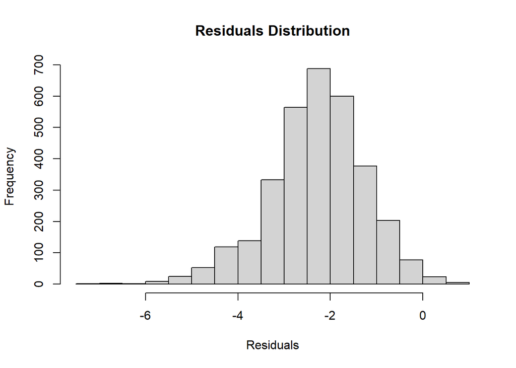

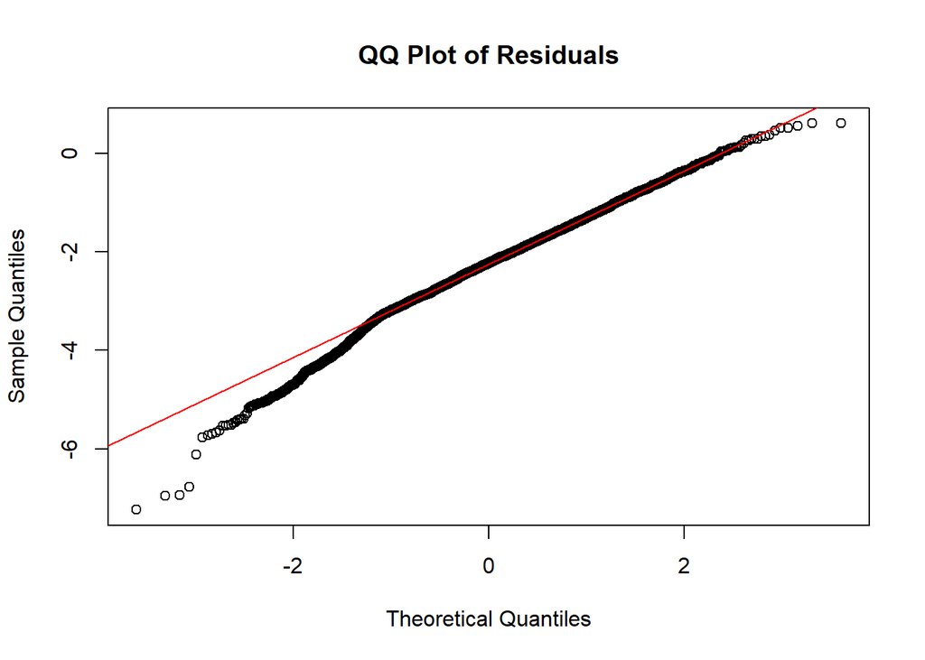

```r
cross_validate_aft_with_residuals <- function(data, formula, dist = "weibull", k = 5) {
  cindex_results <- c()
  residuals_list <- list()
  set.seed(123)  # 确保结果可复现
  folds <- cut(seq(1, nrow(data)), breaks = k, labels = FALSE)

  for (i in 1:k) {
    # 划分训练集和测试集
    test_idx <- which(folds == i, arr.ind = TRUE)
    train_data <- data[-test_idx, ]
    test_data <- data[test_idx, ]

    # 拟合 AFT 模型
    aft_model <- survreg(formula, data = train_data, dist = dist)

    # 预测测试集生存时间
    predictions <- predict(aft_model, newdata = test_data, type = "response")

    # 计算 C-index
    concordance_result <- concordance(Surv(test_data$survival_months, test_data$status) ~ predictions)
    cindex_results <- c(cindex_results, concordance_result$concordance)

    # 计算残差
    train_residuals <- residuals(aft_model, type = "response")
    residuals_list[[i]] <- train_residuals


    # 绘制残差分布图（仅示例第一个 fold）
    if (i == 1) {
      print("Residuals Distribution for Fold 1:")
      hist(train_residuals, main = "Residuals Distribution", xlab = "Residuals")
      qqnorm(train_residuals, main = "QQ Plot of Residuals")
      qqline(train_residuals, col = "red")
    }
  }

  # 返回交叉验证结果和残差信息
  return(list(
    mean_cindex = mean(cindex_results),
    sd_cindex = sd(cindex_results),
    residuals = residuals_list
  ))
}

# 执行交叉验证并检查残差
cv_results_with_residuals <- cross_validate_aft_with_residuals(data_clean, aft_formula, dist = "weibull", k = 5)
```

```r
# 输出交叉验证结果
print("5-Fold Cross-Validation Results with Residual Analysis:")
```

```
## [1] "5-Fold Cross-Validation Results with Residual Analysis:"
```

```r
print(cv_results_with_residuals$mean_cindex)
```

```
## [1] 0.7247365
```

```r
print(cv_results_with_residuals$sd_cindex)
```

```
## [1] 0.01767357
```

# Outliers

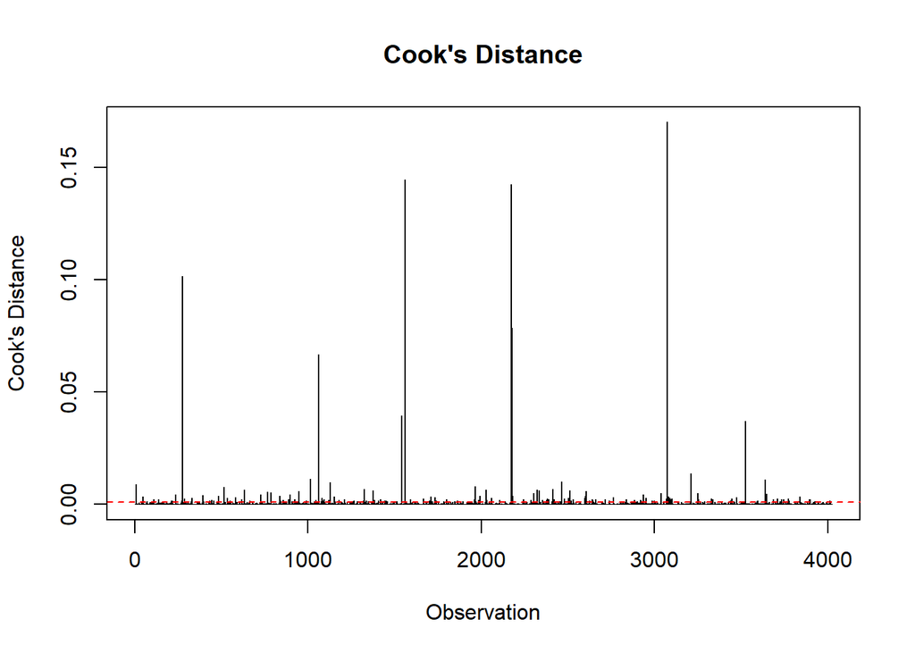

```r
aft_model_outliner <- survreg(aft_formula, data = data_clean, dist = "weibull")


# Residuals
residuals <- residuals(aft_model_outliner, type = "deviance")

# Leverage (hat values)
X <- model.matrix(aft_model_outliner)  # Design matrix
H <- X %*% solve(t(X) %*% X) %*% t(X)  # Hat matrix
leverage <- diag(H)

# Number of parameters
p <- length(coef(aft_model_outliner))

# Cook's Distance
cooks_distance <- (residuals^2 / p) * (leverage / (1 - leverage)^2)

# Plot Cook's distance
plot(cooks_distance, type = "h", main = "Cook's Distance", xlab = "Observation", ylab = "Cook's Distance")
abline(h = 4 / nrow(data_clean), col = "red", lty = 2)
```

```r
# Identify observations with high Cook's distance
outliers <- which(cooks_distance > 4 / nrow(data_clean))
print(unname(outliers))
```

```
##   [1]    9   10   47   72   99  101  112  138  160  185  212  213  216  239  271
##  [16]  278  289  290  295  329  332  395  397  432  446  458  483  518  523  536
##  [31]  551  581  617  619  632  634  664  680  729  731  768  787  839  844  858
##  [46]  868  878  888  897  898  909  923  948  990 1014 1040 1043 1047 1054 1062
##  [61] 1077 1083 1089 1093 1121 1129 1152 1157 1179 1213 1247 1262 1268 1287 1321
##  [76] 1326 1336 1347 1378 1385 1407 1421 1443 1453 1460 1494 1497 1513 1540 1541
##  [91] 1542 1561 1568 1591 1668 1703 1710 1712 1717 1732 1740 1752 1786 1800 1846
## [106] 1862 1894 1962 1964 1969 1987 1995 2029 2032 2059 2107 2108 2140 2173 2178
## [121] 2183 2243 2247 2288 2305 2324 2335 2340 2353 2355 2379 2381 2390 2409 2411
## [136] 2412 2420 2424 2455 2463 2481 2503 2511 2518 2532 2547 2600 2601 2605 2608
## [151] 2625 2642 2645 2662 2715 2716 2718 2740 2762 2805 2832 2837 2876 2882 2886
## [166] 2899 2922 2930 2935 2953 2989 3000 3038 3069 3074 3083 3090 3096 3103 3136
## [181] 3139 3207 3213 3249 3254 3278 3288 3328 3331 3337 3440 3446 3457 3475 3501
## [196] 3516 3526 3527 3592 3595 3639 3641 3647 3664 3687 3712 3725 3727 3732 3746
## [211] 3772 3776 3839 3841 3883 3894 3897 3927 3975 4014 4018
```

```r
# Exclude outliers from the data
data_clean_no_outliers <- data_clean[-outliers, ]

# Refit the AFT model without outliers
survreg(formula = aft_formula, data = data_clean_no_outliers, dist = "weibull")
```

```
## Call:
## survreg(formula = aft_formula, data = data_clean_no_outliers,
##     dist = "weibull")
##
## Coefficients: (7 not defined because of singularities)
##                                                    (Intercept)
##                                                   2.060185e+00
##                                                      n_stageN2
##                                                  -5.217455e-02
##                                                      n_stageN3
##                                                   1.247264e-01
##                                         regional_node_positive
##                                                  -1.529082e-02
##                                         regional_node_examined
##                                                   1.739459e-03
##                                        estrogen_statusPositive
##                                                  -5.892407e-02
##                                    progesterone_statusPositive
##                                                   2.339152e-01
##                                                      t_stageT2
##                                                  -1.308981e-02
##                                                      t_stageT3
##                                                  -3.418106e-03
##                                                      t_stageT4
##                                                   1.779677e+00
##                             differentiatePoorly differentiated
##                                                  -1.416786e-01
##                                  differentiateUndifferentiated
##                                                  -2.508863e-01
##                               differentiateWell differentiated
##                                                  -2.327850e-02
##                                                            age
##                                                  -3.324524e-03
##                                                      raceOther
##                                                   1.422361e-01
##                                                      raceWhite
##                                                   6.960558e-02
##                               n_stageN2:regional_node_positive
##                                                   3.413877e-04
##                               n_stageN3:regional_node_positive
```

[output cut: 60 more lines]

```
##                                                             NA
##                        t_stageT4:differentiateUndifferentiated
##                                                             NA
##                     t_stageT2:differentiateWell differentiated
##                                                  -1.204619e-01
##                     t_stageT3:differentiateWell differentiated
##                                                   1.665395e+00
##                     t_stageT4:differentiateWell differentiated
##                                                   1.707889e+00
##
## Scale= 0.1061434
##
## Loglik(model)= -1340.2   Loglik(intercept only)= -1576.1
##  Chisq= 471.66 on 51 degrees of freedom, p= <2e-16
## n= 3803
```